# Coursera - Data Science Specialization - Practical Machine Learning - Peer Graded Assignment

Antonio Belard

9 de Maio de 2019

# Introduction

Using devices such as Jawbone Up, Nike FuelBand, and Fitbit it is now possible to collect a large amount of data about personal activity relatively inexpensively.

These type of devices are part of the quantified self movement – a group of enthusiasts who take measurements about themselves regularly to improve their health, to find patterns in their behavior, or because they are tech geeks. One thing that people regularly do is quantify how much of a particular activity they do, but they rarely quantify how well they do it.

In this project, your goal will be to use data from accelerometers on the belt, forearm, arm, and dumbell of 6 participants. They were asked to perform barbell lifts correctly and incorrectly in 5 different ways. More information is available from the website here: http://groupware.les.inf.puc-rio.br/har (see the section on the Weight Lifting Exercise Dataset).

The goal of this project is to classify (predict) the manner in which they did the exercise. This is the “classe” variable in the training set.

For that matter we will build, analyze and compare the following classifiers:

- A Decision Tree classifier
- A Random Forest classifier
- A Gradient Boosting Machine classifier

We will then choose the best one of them and procede using it to predict 20 new and different test cases.

# Data Inspection

The data to be used comes in two files:

- **“pml-training.csv”:** Data that will be used to train and test the classifiers
- **“pml-testing.csv”:** Data that will serve to predict the 20 new and different test cases.

We start by inspecting the two files in a text editor.

From that inspection we can see that:

- The data features separator is a comma
- There are several missing values in the dataset, the usual NAs as well as some other ‘#DIV/0!’ that seem to be the result of formula error on excel
- The file has a header with the features names
- The first feature of the dataset is actually the row number

# Data Loading

Based on what we have learned at data inspection we load both datasets.

```r
training <- read.table("pml-training.csv", header = TRUE, sep = ",", na.strings = c("NA", "#DIV/0!", ""))
testing <- read.table("pml-testing.csv", header = TRUE, sep = ",", na.strings = c("NA", "#DIV/0!", ""))

training.dims <- dim(training)
testing.dims <- dim(testing)

training.rows <- training.dims[1]
training.features <- training.dims[2]

testing.rows <- testing.dims[1]
testing.features <- testing.dims[2]
```

We can see that:

- The training dataset has **19622 rows** with **160 features**
- The testing dataset has **20 rows** with **160 features**

# Data Cleansing (see Appendix - Data Cleansing)

We will now procede to clean both datasets. First we take a look the training dataset structure.

We can see that:

- Feature number one, **‘x’**, is just the row number
- Feature number two, **‘user_name’**, is just the user name, it does n’t have any predictive power.
- Features number three to seven, **raw_timestamp_part_1**, **raw_timestamp_part_2**, **cvtd_timestamp**, **new_window**, and **num_window**, are not sensor related, they are time related and since the dataset doesn’t seem to have any time-dependence these features can be simply ignored
- Finally, not all of the existing features will be considered, we will discard features that either contains NA or are not in the testing dataset.

```r
considered.features <- names(testing[,colSums(is.na(testing)) == 0])[8:59]

training <- training[, c(considered.features,"classe")]
testing <- testing[, c(considered.features,"problem_id")]

training.dims <- dim(training)
testing.dims <- dim(testing)

training.rows <- training.dims[1]
training.features <- training.dims[2]

testing.rows <- testing.dims[1]
testing.features <- testing.dims[2]
```

We see that now, after cleaning the data:

- The training dataset has **19622 rows** with **53 features**
- The testing dataset has **20 rows** with **53 features**

# Dataset Partitioning

We are now going to split the training dataset in two parts:

- 80% of the training dataset data will be used for training the classifiers
- The remaining 20% of the training dataset data will be use for testing the resulting classifiers

**Note that this data split on the training dataset data should not be mistaken for the data in the final testing dataset that will be used to make the required new predictions.**

```r
# reproducibility concerns
set.seed(666)

inTrain <- createDataPartition(training$classe, p=0.80, list=FALSE)
training.train <- training[inTrain, ]
training.test <- training[-inTrain, ]

training.train.dims <- dim(training.train)
training.train.rows <- training.train.dims[1]
training.train.features <- training.train.dims[2]

training.test.dims <- dim(training.test)
training.test.rows <- training.test.dims[1]
training.test.features <- training.test.dims[2]
```

After the training dataset split:

- The dataset for training the classifiers has **15699 rows** with **53 features**
- The dataset for testing the classifiers has **3923 rows** with **53 features**

# Classifiers

- A Decision Tree classifier
- A Random Forest Classifier
- A Gradient Boosting Machine Classifier

We will plot and evaluate each of the trained classifiers, and finally choose the best one to make the required new predictions.

The criteria for choosing the best classifier will be based on:

- The obtained classifier **accuracy value**
- The obtained classifier **kappa value** (the classifier accuracy corrected for chance)

We will now build, plot, and evaluate a Decision Tree Classifier on the training dataset.

### Building the Decision Tree Classifier

```r
trControl.decision.tree <- rpart.control(method = "cv", number = 10)
decision.tree.classifier <- rpart(classe ~ ., data = training.train, method="class", control = trControl.decision.tree)
print(decision.tree.classifier)
```

```
## n= 15699
##
## node), split, n, loss, yval, (yprob)
##       * denotes terminal node
##
##     1) root 15699 11235 A (0.28 0.19 0.17 0.16 0.18)
##       2) roll_belt< 130.5 14388  9937 A (0.31 0.21 0.19 0.18 0.11)
##         4) pitch_forearm< -33.95 1270     7 A (0.99 0.0055 0 0 0) *
##         5) pitch_forearm>=-33.95 13118  9930 A (0.24 0.23 0.21 0.2 0.12)
##          10) magnet_dumbbell_y< 432.5 11007  7901 A (0.28 0.18 0.24 0.19 0.11)
##            20) roll_forearm< 122.5 6791  4019 A (0.41 0.18 0.19 0.17 0.06)
##              40) magnet_dumbbell_z< -24.5 2337   755 A (0.68 0.2 0.019 0.073 0.031) *
##              41) magnet_dumbbell_z>=-24.5 4454  3222 C (0.27 0.17 0.28 0.21 0.075)
##                82) yaw_belt>=169.5 516    59 A (0.89 0.043 0 0.07 0.0019) *
##                83) yaw_belt< 169.5 3938  2706 C (0.19 0.18 0.31 0.23 0.084)
##                 166) accel_dumbbell_y>=-40.5 3415  2512 D (0.21 0.2 0.23 0.26 0.092)
##                   332) pitch_belt< -42.95 424    83 B (0.024 0.8 0.1 0.042 0.026) *
##                   333) pitch_belt>=-42.95 2991  2106 D (0.24 0.12 0.24 0.3 0.1)
##                     666) roll_belt>=125.5 719   298 C (0.37 0.029 0.59 0.011 0.0042)
##                      1332) magnet_belt_z< -326.5 226     4 A (0.98 0 0.0044 0 0.013) *
##                      1333) magnet_belt_z>=-326.5 493    73 C (0.089 0.043 0.85 0.016 0) *
##                     667) roll_belt< 125.5 2272  1395 D (0.2 0.15 0.14 0.39 0.13)
##                      1334) pitch_belt>=1.3 1403  1076 A (0.23 0.22 0.15 0.21 0.19)
##                        2668) yaw_forearm>=-99.15 1119   792 A (0.29 0.25 0.14 0.081 0.23)
##                          5336) accel_dumbbell_z< 25.5 642   335 A (0.48 0.19 0.24 0.055 0.037)
##                           10672) magnet_forearm_z>=-125.5 408   108 A (0.74 0.14 0.02 0.071 0.032) *
##                           10673) magnet_forearm_z< -125.5 234    86 C (0.03 0.26 0.63 0.026 0.047) *
##                          5337) accel_dumbbell_z>=25.5 477   242 E (0.042 0.35 0.0021 0.12 0.49)
##                           10674) roll_dumbbell< 36.19782 155    23 B (0.026 0.85 0.0065 0.032 0.084) *
##                           10675) roll_dumbbell>=36.19782 322   100 E (0.05 0.1 0 0.16 0.69) *
##                        2669) yaw_forearm< -99.15 284    76 D (0 0.063 0.17 0.73 0.039) *
##                      1335) pitch_belt< 1.3 869   291 D (0.14 0.037 0.12 0.67 0.033)
##                        2670) yaw_arm< -101.05 116     0 A (1 0 0 0 0) *
##                        2671) yaw_arm>=-101.05 753   175 D (0.011 0.042 0.14 0.77 0.039) *
##                 167) accel_dumbbell_y< -40.5 523    66 C (0.011 0.046 0.87 0.033 0.036) *
##            21) roll_forearm>=122.5 4216  2845 C (0.079 0.18 0.33 0.23 0.19)
##              42) magnet_dumbbell_y< 291.5 2482  1301 C (0.095 0.13 0.48 0.15 0.14)
##                84) magnet_dumbbell_z>=284.5 371   187 A (0.5 0.14 0.043 0.094 0.23) *
##                85) magnet_dumbbell_z< 284.5 2111   946 C (0.025 0.13 0.55 0.16 0.13)
##                 170) pitch_belt>=26.15 170    35 B (0.1 0.79 0.035 0 0.071) *
##                 171) pitch_belt< 26.15 1941   782 C (0.018 0.075 0.6 0.18 0.13) *
##              43) magnet_dumbbell_y>=291.5 1734  1144 D (0.057 0.25 0.11 0.34 0.25)
##                86) accel_forearm_x>=-100.5 1097   717 E (0.052 0.31 0.15 0.14 0.35)
##                 172) roll_dumbbell< 40.19426 227    50 B (0.044 0.78 0 0.062 0.11) *
##                 173) roll_dumbbell>=40.19426 870   516 E (0.054 0.19 0.19 0.16 0.41) *
##                87) accel_forearm_x< -100.5 637   201 D (0.064 0.14 0.035 0.68 0.08) *
##          11) magnet_dumbbell_y>=432.5 2111  1049 B (0.039 0.5 0.043 0.23 0.19)
##            22) total_accel_dumbbell>=5.5 1523   553 B (0.054 0.64 0.058 0.028 0.22)
##              44) roll_belt>=-0.59 1296   326 B (0.063 0.75 0.068 0.032 0.088) *
##              45) roll_belt< -0.59 227     0 E (0 0 0 0 1) *
##            23) total_accel_dumbbell< 5.5 588   155 D (0 0.16 0.0051 0.74 0.1) *
##       3) roll_belt>=130.5 1311    13 E (0.0099 0 0 0 0.99) *
```

### Plotting the Decision Tree Classifier

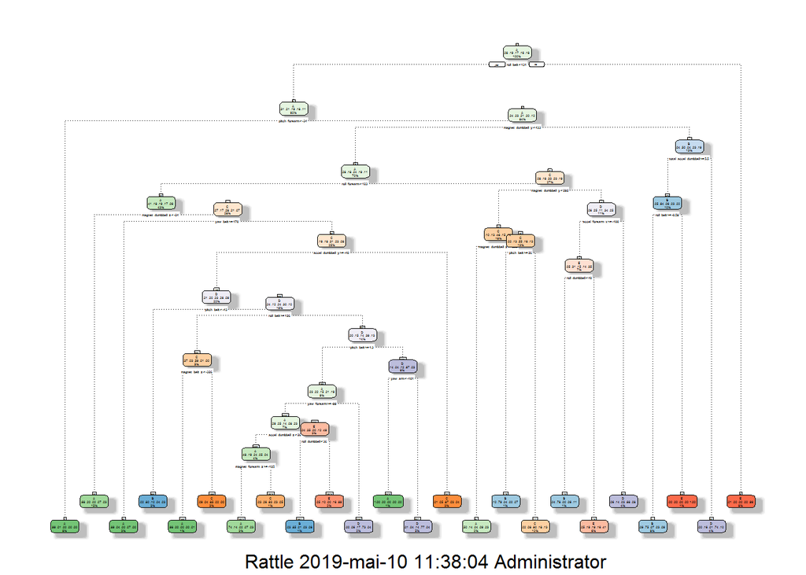

```r
fancyRpartPlot(decision.tree.classifier)
```

### Evaluating the Decision Tree Classifier

```r
decision.tree.classifier.prediction <- predict(decision.tree.classifier, training.test, type = "class")
decision.tree.classifier.confusion.matrix <- confusionMatrix(decision.tree.classifier.prediction, training.test$classe)

decision.tree.classifier.accuracy <- decision.tree.classifier.confusion.matrix$overall['Accuracy']
decision.tree.classifier.k <- decision.tree.classifier.confusion.matrix$overall['Kappa']

decision.tree.classifier.confusion.matrix
```

```
## Confusion Matrix and Statistics
##
##           Reference
## Prediction    A    B    C    D    E
##          A 1027  166   23   86   41
##          B   34  414   35   12   34
##          C   25   70  551   86   76
##          D   16   41   28  401   39
##          E   14   68   47   58  531
##
## Overall Statistics
##
##                Accuracy : 0.7453
##                  95% CI : (0.7314, 0.7589)
##     No Information Rate : 0.2845
##     P-Value [Acc > NIR] : < 2.2e-16
##
##                   Kappa : 0.6756
##
##  Mcnemar's Test P-Value : < 2.2e-16
##
## Statistics by Class:
##
##                      Class: A Class: B Class: C Class: D Class: E
## Sensitivity            0.9203   0.5455   0.8056   0.6236   0.7365
## Specificity            0.8874   0.9637   0.9207   0.9622   0.9416
## Pos Pred Value         0.7647   0.7826   0.6819   0.7638   0.7396
## Neg Pred Value         0.9655   0.8984   0.9573   0.9288   0.9407
## Prevalence             0.2845   0.1935   0.1744   0.1639   0.1838
## Detection Rate         0.2618   0.1055   0.1405   0.1022   0.1354
## Detection Prevalence   0.3423   0.1348   0.2060   0.1338   0.1830
## Balanced Accuracy      0.9038   0.7546   0.8631   0.7929   0.8390
```

We can see that the Decision Tree Classifier has:

- An obtained **accuracy value of 74.53%**
- An obtained **kappa value of 67.56%**

## The Random Forest Classifier (see Appendix - The Random Forest Classifier)

We will now build, plot, and evaluate a Random Forest Classifier on the training dataset.

### Building the Random Forest Classifier

```r
trControl.random.forest <- trainControl(method = "cv", classProbs=TRUE, savePredictions=TRUE, allowParallel=TRUE, number = 10, search = "grid")

random.forest.classifier <- randomForest(classe ~ ., data = training.train, method = "rf", importance = TRUE, trControl = trControl.random.forest, proximity=TRUE)

print(random.forest.classifier)
```

```
##
## Call:
##  randomForest(formula = classe ~ ., data = training.train, method = "rf",      importance = TRUE, trControl = trControl.random.forest, proximity = TRUE)
##                Type of random forest: classification
##                      Number of trees: 500
## No. of variables tried at each split: 7
##
##         OOB estimate of  error rate: 0.41%
## Confusion matrix:
##      A    B    C    D    E  class.error
## A 4460    3    0    0    1 0.0008960573
## B   10 3024    4    0    0 0.0046082949
## C    0   11 2722    5    0 0.0058436815
## D    0    0   21 2549    3 0.0093276331
## E    0    0    1    6 2879 0.0024255024
```

### Plotting the Random Forest Classifier

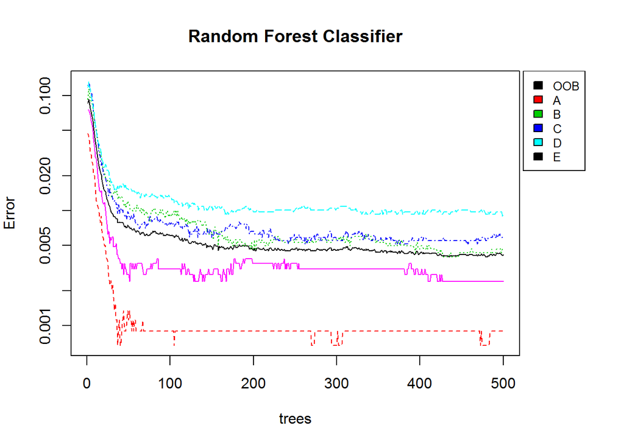

```r
layout(matrix(c(1,2),nrow=1), width=c(5,1))
par(mar=c(5,4,4,0)) #No margin on the right side
plot(random.forest.classifier, main="Random Forest Classifier", log="y")
par(mar=c(5,0,4,2)) #No margin on the left side
plot(c(0,1),type="n", axes=F, xlab="", ylab="")
legend("top", colnames(random.forest.classifier$err.rate),col=1:5,cex=0.8,fill=1:5)
```

In the plot we can see that:

- The Out-of-bag error (OOB) is very low, 0.41%
- The Classifier predicts some classes better than others, classe ‘A’ being the better predicted and classe ‘D’ being the worse predicted.

### Evaluating the Random Forest Classifier

```r
random.forest.classifier.prediction <- predict(random.forest.classifier, training.test, type = "class")
random.forest.classifier.confusion.matrix <- confusionMatrix(random.forest.classifier.prediction, training.test$classe)

random.forest.classifier.accuracy <- random.forest.classifier.confusion.matrix$overall['Accuracy']
random.forest.classifier.k <- random.forest.classifier.confusion.matrix$overall['Kappa']

random.forest.classifier.confusion.matrix
```

```
## Confusion Matrix and Statistics
##
##           Reference
## Prediction    A    B    C    D    E
##          A 1116    4    0    0    0
##          B    0  753    1    0    0
##          C    0    2  683    5    3
##          D    0    0    0  638    4
##          E    0    0    0    0  714
##
## Overall Statistics
##
##                Accuracy : 0.9952
##                  95% CI : (0.9924, 0.9971)
##     No Information Rate : 0.2845
##     P-Value [Acc > NIR] : < 2.2e-16
##
##                   Kappa : 0.9939
##
##  Mcnemar's Test P-Value : NA
##
## Statistics by Class:
##
##                      Class: A Class: B Class: C Class: D Class: E
## Sensitivity            1.0000   0.9921   0.9985   0.9922   0.9903
## Specificity            0.9986   0.9997   0.9969   0.9988   1.0000
## Pos Pred Value         0.9964   0.9987   0.9856   0.9938   1.0000
## Neg Pred Value         1.0000   0.9981   0.9997   0.9985   0.9978
## Prevalence             0.2845   0.1935   0.1744   0.1639   0.1838
## Detection Rate         0.2845   0.1919   0.1741   0.1626   0.1820
## Detection Prevalence   0.2855   0.1922   0.1767   0.1637   0.1820
## Balanced Accuracy      0.9993   0.9959   0.9977   0.9955   0.9951
```

We can see that the Random Forest Classifier has:

- An obtained **accuracy value of 99.52%**
- An obtained **kappa value of 99.39%**

## The Gradient Boosting Machine Classifier

### Building the Gradient Boosting Machine Classifier

```r
trControl.boosting <- trainControl(method = "cv", number = 10)
boosting.classifier <- train(classe ~ ., method = "gbm", data = training.test, verbose = FALSE, trControl = trControl.boosting)

boosting.classifier
```

```
## Stochastic Gradient Boosting
##
## 3923 samples
##   52 predictor
##    5 classes: 'A', 'B', 'C', 'D', 'E'
##
## No pre-processing
## Resampling: Cross-Validated (10 fold)
## Summary of sample sizes: 3531, 3530, 3532, 3531, 3530, 3533, ...
## Resampling results across tuning parameters:
##
##   interaction.depth  n.trees  Accuracy   Kappa
##   1                   50      0.7517367  0.6851693
##   1                  100      0.8009302  0.7481176
##   1                  150      0.8335647  0.7894112
##   2                   50      0.8361021  0.7922490
##   2                  100      0.8875746  0.8576713
##   2                  150      0.9117912  0.8883640
##   3                   50      0.8776424  0.8450252
##   3                  100      0.9217279  0.9009260
##   3                  150      0.9395735  0.9235412
##
## Tuning parameter 'shrinkage' was held constant at a value of 0.1
##
## Tuning parameter 'n.minobsinnode' was held constant at a value of 10
## Accuracy was used to select the optimal model using the largest value.
## The final values used for the model were n.trees = 150,
##  interaction.depth = 3, shrinkage = 0.1 and n.minobsinnode = 10.
```

### Plotting the Gradient Boosting Machine Classifier

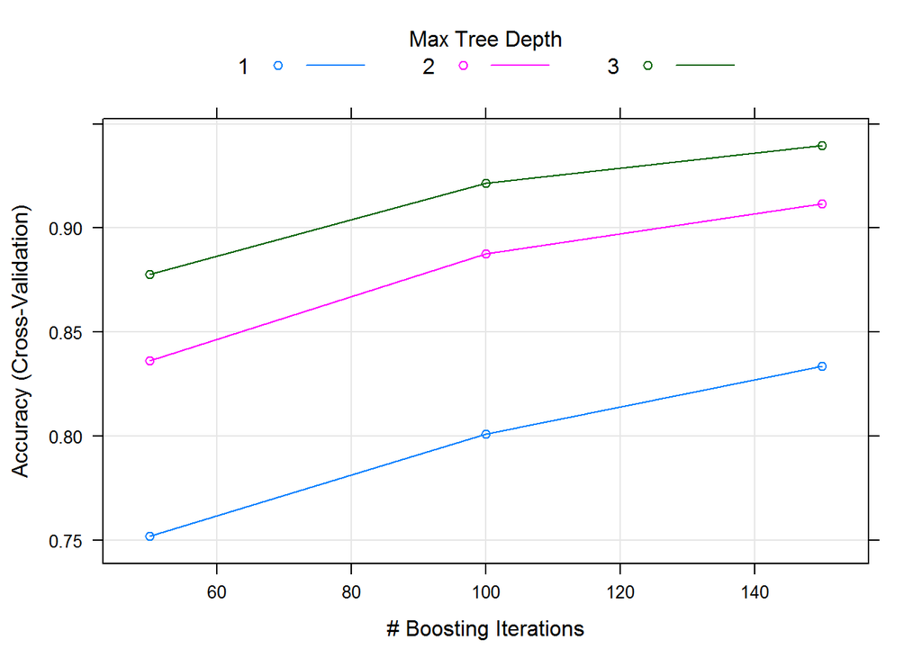

```r
plot(boosting.classifier)
```

In the plot we can see that the Gradient Boosting Machine Classifier accuracy grows both with tree depth and boosting interactions.

### Evaluating the Gradient Boosting Machine Classifier

```r
boosting.classifier.prediction <- predict(boosting.classifier, training.test)
boosting.classifier.confusion.matrix <- confusionMatrix(boosting.classifier.prediction, training.test$classe)

boosting.classifier.accuracy <- boosting.classifier.confusion.matrix$overall['Accuracy']
boosting.classifier.k <- boosting.classifier.confusion.matrix$overall['Kappa']

boosting.classifier.confusion.matrix
```

```
## Confusion Matrix and Statistics
##
##           Reference
## Prediction    A    B    C    D    E
##          A 1109    9    0    0    0
##          B    5  741   12    1    2
##          C    1    8  670    9    4
##          D    0    1    2  631    8
##          E    1    0    0    2  707
##
## Overall Statistics
##
##                Accuracy : 0.9834
##                  95% CI : (0.9789, 0.9872)
##     No Information Rate : 0.2845
##     P-Value [Acc > NIR] : < 2.2e-16
##
##                   Kappa : 0.979
##
##  Mcnemar's Test P-Value : NA
##
## Statistics by Class:
##
##                      Class: A Class: B Class: C Class: D Class: E
## Sensitivity            0.9937   0.9763   0.9795   0.9813   0.9806
## Specificity            0.9968   0.9937   0.9932   0.9966   0.9991
## Pos Pred Value         0.9919   0.9737   0.9682   0.9829   0.9958
## Neg Pred Value         0.9975   0.9943   0.9957   0.9963   0.9956
## Prevalence             0.2845   0.1935   0.1744   0.1639   0.1838
## Detection Rate         0.2827   0.1889   0.1708   0.1608   0.1802
## Detection Prevalence   0.2850   0.1940   0.1764   0.1637   0.1810
## Balanced Accuracy      0.9953   0.9850   0.9864   0.9890   0.9898
```

We can see that the Gradient Boosting Machine classifier has:

- An obtained **accuracy value of 98.34%**
- An obtained **kappa value of 97.9%**

## Choosing the Best Classifier

**Without further parametrization of the classifiers** and comparing the obtained values we can see that:

- The **best** one is the **Random Forest Classifier** with an **accuracy value of 99.52%** and a **kappa value of 99.39%**
- The **second best** is the **Gradient Boosting Machine Classifier** with an **accuracy value of 98.34%** and a **kappa value of 97.9%**
- Lastly, being the **worse** of them all, comes the **Decision Tree Classifier** with an **accuracy value of 74.53%** and a **kappa value of 67.56%**

**Note that normally, with further parametrization, it would be expected that the Gradient Boosting Machine performs better than the Random Forest Tree classifier.**

## Making New Predictions

We are now going to make the required new predictions by using the the **Random Forest Classifier.**

```r
random.forest.prediction.on.testing.data <- predict(random.forest.classifier, testing)
random.forest.prediction.on.testing.data
```

```
##  1  2  3  4  5  6  7  8  9 10 11 12 13 14 15 16 17 18 19 20
##  B  A  B  A  A  E  D  B  A  A  B  C  B  A  E  E  A  B  B  B
## Levels: A B C D E
```

# Appendix

## Data Cleansing

### Data Structure Before Cleansing

```r
str(data_before_cleansing)
```

[output not shown]

[output cut: 39 more lines]

### Data Structure After Cleansing

```r
str(data_after_cleansing)
```

```
## 'data.frame':    19622 obs. of  53 variables:
##  $ roll_belt           : num  1.41 1.41 1.42 1.48 1.48 1.45 1.42 1.42 1.43 1.45 ...
##  $ pitch_belt          : num  8.07 8.07 8.07 8.05 8.07 8.06 8.09 8.13 8.16 8.17 ...
##  $ yaw_belt            : num  -94.4 -94.4 -94.4 -94.4 -94.4 -94.4 -94.4 -94.4 -94.4 -94.4 ...
##  $ total_accel_belt    : int  3 3 3 3 3 3 3 3 3 3 ...
##  $ gyros_belt_x        : num  0 0.02 0 0.02 0.02 0.02 0.02 0.02 0.02 0.03 ...
##  $ gyros_belt_y        : num  0 0 0 0 0.02 0 0 0 0 0 ...
##  $ gyros_belt_z        : num  -0.02 -0.02 -0.02 -0.03 -0.02 -0.02 -0.02 -0.02 -0.02 0 ...
##  $ accel_belt_x        : int  -21 -22 -20 -22 -21 -21 -22 -22 -20 -21 ...
##  $ accel_belt_y        : int  4 4 5 3 2 4 3 4 2 4 ...
##  $ accel_belt_z        : int  22 22 23 21 24 21 21 21 24 22 ...
##  $ magnet_belt_x       : int  -3 -7 -2 -6 -6 0 -4 -2 1 -3 ...
##  $ magnet_belt_y       : int  599 608 600 604 600 603 599 603 602 609 ...
##  $ magnet_belt_z       : int  -313 -311 -305 -310 -302 -312 -311 -313 -312 -308 ...
##  $ roll_arm            : num  -128 -128 -128 -128 -128 -128 -128 -128 -128 -128 ...
```

[output cut: 39 more lines]

## The Random Forest Classifier

### Features Importance

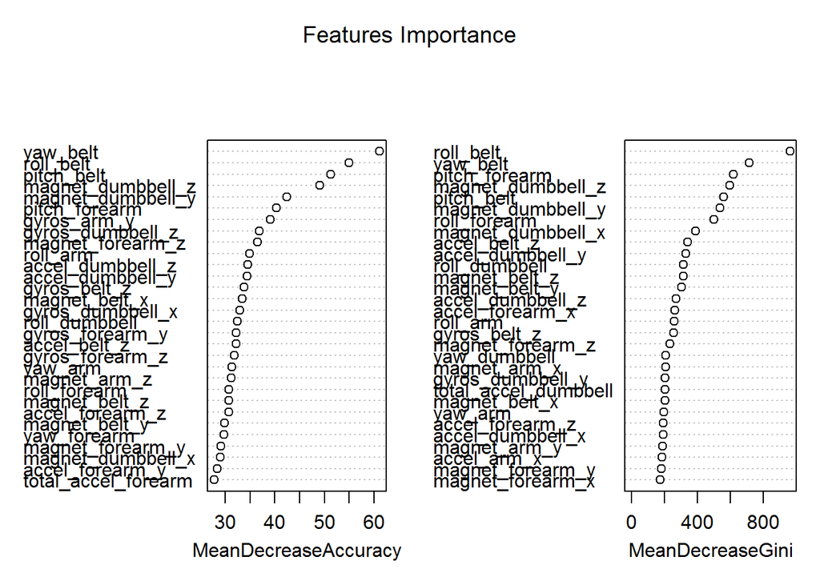

```r
varImpPlot(random.forest.classifier, main="Features Importance")
```